# Beyond the Playbook: Unveiling the Hidden Dynamics of NFL Success through Climate, Betting, Crime, and Quarterback Insights

## Team Members:

- Ishan Saksena (saksena)
- Sandeep Jala (jsandeep)
- Konstantinos Sarinopoulos (ksarinop)

## Overview

Our project studies the correlation across a range of datasets: NFL statistics, weather, betting odds, quarterback performance, and crime data, with an end goal to develop a machine learning model for predicting NFL game outcomes. By analyzing these diverse data sets, the project aims to uncover hidden factors affecting team performance and offer a comprehensive prediction model that goes beyond traditional analytics, providing insights into the multifaceted influences on NFL games. We also aim to study correlations between the data, such as crime with betting, quarterback performance and the weather.

## Motivation

The three of us are sports fans with an interest in true crime, and we were looking for ways to combine these interests. We chose this project because we're interested in finding out how different factors, like weather, betting odds, quarterback performance, and crime rates, can affect NFL games beyond just the usual stats. We believe by looking at these various elements together, we can uncover new insights and improve predictions on game outcomes, offering a fresh perspective to fans, bettors, and teams.

## Questions

- How do weather conditions affect the performance of home and away teams, especially in terms of scoring?:

Determine if weather factors like temperature, wind, and precipitation disproportionately affect the home or away teams, possibly due to familiarity with local conditions or weather-specific preparation.

- Does the crime rate in a team's state correlate with the team's performance, particularly home game outcomes?:

Investigate if higher crime rates in a team's state are associated with things like poorer home game performance. It can suggest things like external societal pressures or distractions could influence player focus or team cohesion. It could also see patterns between violent crime and the NFL’s violence.

- How do betting odds correlate with actual team performance and game outcomes in the NFL?:

By examining the relationship between the fluctuations in betting odds and the subsequent performance of teams in games, we aim to uncover patterns that might indicate how accurately the betting market anticipates real game outcomes.

- How does the presence of high-profile quarterbacks influence betting odds and public perception, regardless of the team's overall performance?:

Determine the effect of star quarterbacks on betting odds and public perception, revealing whether the presence of marquee players skews betting markets beyond what statistics alone would justify.

### Other Questions:

- Is there a correlation between local socioeconomic factors (reflected indirectly by crime data) and the betting market's expectations for a team's performance?:

Analyze how socioeconomic indicators, inferred from crime rates, correlate with betting odds to see if external factors influence public and market perceptions of team prospects.

- Can quarterback performance metrics predict the outcome of a game more accurately than betting odds?:

Assess the predictive accuracy of detailed quarterback metrics compared to betting odds, aiming to identify if nuanced player performance insights offer a better prediction model than the general betting consensus.

- How does the betting market react to weather conditions on game day?:

Analyze how weather data is correlated with the betting market and winning conditions.

## Data Sources

### Links:

- NFL dataset: https://github.com/cooperdff/nfl_data_py/tree/main/data
- Betting data + weather data: https://www.kaggle.com/datasets/tobycrabtree/nfl-scores-and-betting-data/data
- Robbery data: https://ucr.fbi.gov/crime-in-the-u.s/2016/crime-in-the-u.s.-2016/tables/table-13
- Aggravated Assaults data: https://ucr.fbi.gov/crime-in-the-u.s/2016/crime-in-the-u.s.-2016/tables/table-14
- Quarterback Statistics data: https://fftoday.com/stats/

### How do the datasets complement each other?

- **NFL Statistics Dataset**: This dataset includes game-by-game statistics such as scores, team performances, win/loss records, and player stats. It provides the foundational data for understanding the outcomes of games and the performance metrics of teams and individual players.
- **Weather Dataset**: Contains detailed information about weather conditions for each game, including temperature, wind speed, humidity, and specific weather events (rain, snow, etc.). Weather conditions can significantly affect game strategies and player performance, especially in outdoor stadiums, making this dataset crucial for analyzing game outcomes in relation to environmental factors.
- **Betting Odds Dataset**: Offers insights into how games are perceived by the public and the betting markets before they happen, including the favored team and predicted point spreads and over/under lines. This dataset helps gauge public expectations and market sentiment, which can be compared against actual game outcomes and weather conditions to identify patterns or biases.
- **Quarterback Performance Dataset**: Focuses on the performance metrics of starting quarterbacks, such as touchdowns, completions, and passing yards. Quarterbacks play a pivotal role in their teams' offensive strategies, making their performance data essential for analyzing its impact on game outcomes, especially when cross-referenced with weather conditions and betting odds.
- **Crime Data Dataset**: There are 2 datasets, one on Robbery and one on Aggravated Assault. These datasets offer a unique perspective on the socio-economic environment surrounding the teams, potentially correlating with team performance, fan engagement, and even betting odds. It allows for the exploration of how external societal factors might influence or reflect the dynamics of NFL games.

### Data Description

#### Size of datasets:

- NFL DATA (Schedule.csv): (267, 18)
- BETTING + WEATHER (Betting_weather.csv): (13801,15)
- ROBBERY (table_13.csv): (54,10)
- ASSAULTS (table_14.csv): (54,8)
- QB STATS( nfl_qb_stats.csv): (71,13)
- Merged_data size: (222, 45)

#### Missing values:

- Weather_detail: It had 147 missing values after merging. After research, we discovered that these were standard (Sunny/Cloudy) days, and labeled them as such.
- Quarterback data: Los Angeles has multiple teams, and 2 of them were labeled as LAR in our dataset (LA Rams and LA Raiders), causing some missing values. We fixed this by researching and merging correctly.
- Stadium: some of the stadiums were not in the USA. These games were dropped.

#### Variables:

- `schedule_date`: The date the game was played.
- `schedule_playoff`: Indicator of whether the game was part of the playoffs.
- `team_home`: The home team for the game.
- `team_away`: The visiting team.
- `team_favorite_id`: The team favored to win, based on betting odds.
- `spread_favorite`: The point spread for the favored team.
- `over_under_line`: The predicted total points for the game by bettors.
- `stadium`: The stadium where the game was played.
- `weather_temperature`: Game day temperature.
- `weather_wind_mph`: Wind speed in miles per hour during the game.
- `weather_detail`: Specific weather conditions, e.g., rain, snow.
- `state`: The state where the game was played.
- `game_id`: A unique identifier for the game.
- `game_type`: Type of game, e.g., regular season, playoff.
- `gametime`: The time the game started.
- `away_score`: Final score for the away team.
- `home_score`: Final score for the home team.
- `home_result`: Outcome for the home team (win/loss).
- `roof`: Type of stadium roof, e.g., open, closed.
- `surface`: Type of playing surface, e.g., grass, turf.
- `old_game_id`: Possibly an alternate or previous game identifier.
- `home_win`: Indicator of a home team win.
- `away_win`: Indicator of an away team win.
- `tie`: Indicator of a game tie.
- `Total Aggravated Assaults`: Number of reported aggravated assaults.
- `Population`: Population of the area.
- `Total Robberies`: Total number of robberies.
- `home_qb`: The starting quarterback for the home team.
- `away_qb`: The starting quarterback for the away team.
- `matches_qb`: The total matches the quarterback played for the home team.
- `matches_qb`: The total matches the quarterback played for the away team.
- `TD_QB_home`: Touchdowns scored by the home team's quarterback.
- `TD_QB_away`: Touchdowns scored by the away team's quarterback.
- `Comp_QB_home`: Pass completions by the home team's quarterback.
- `Comp_QB_away`: Pass completions by the away team's quarterback.
- `Yards_QB_home`: Passing yards by the home team's quarterback.
- `Yards_QB_away`: Passing yards by the away team's quarterback.

```python
import pandas as pd
import numpy as np
import matplotlib.pyplot as plt
import seaborn as sns
```

```python
schedule = pd.read_csv('schedule.csv')
betting_weather_df = pd.read_csv('betting_weather.csv')
crime_data = pd.read_csv('table-14.csv')
robbery_data = pd.read_csv('table-13.csv')
nfl_qb_stats = pd.read_csv('nfl qb stats.csv')
```

Loading the data using pandas read csv.

There are total of 5 datasets:

- NFL Schedule
- NFL Betting Odds + Weather Data
- Crime Data
- Robbery Data
- NFL Quarterback player states

```python
schedule.sample(5)
```

|  | Unnamed: 0 | game_id | season | game_type | week | gameday | weekday | gametime | away_team | home_team | away_score | home_score | home_result | stadium | location | roof | surface | old_game_id |
| --- | --- | --- | --- | --- | --- | --- | --- | --- | --- | --- | --- | --- | --- | --- | --- | --- | --- | --- |
| 12 | 12 | 2016_01_DET_IND | 2016 | REG | 1 | 9/11/2016 | Sunday | 16:25 | DET | IND | 39 | 35 | -4 | Lucas Oil Stadium | Home | open | fieldturf | 2016091111 |
| 73 | 73 | 2016_05_BUF_LA | 2016 | REG | 5 | 10/9/2016 | Sunday | 16:25 | BUF | LA | 30 | 19 | -11 | Los Angeles Memorial Coliseum | Home | outdoors | grass | 2016100909 |
| 186 | 186 | 2016_13_BUF_OAK | 2016 | REG | 13 | 12/4/2016 | Sunday | 16:05 | BUF | OAK | 24 | 38 | 14 | Oakland-Alameda County Coliseum | Home | outdoors | grass | 2016120408 |
| 85 | 85 | 2016_06_CLE_TEN | 2016 | REG | 6 | 10/16/2016 | Sunday | 13:00 | CLE | TEN | 26 | 28 | 2 | Nissan Stadium | Home | outdoors | grass | 2016101607 |
| 120 | 120 | 2016_09_ATL_TB | 2016 | REG | 9 | 11/3/2016 | Thursday | 20:25 | ATL | TB | 43 | 28 | -15 | Raymond James Stadium | Home | outdoors | grass | 2016110300 |

```python
schedule.describe()
```

|  | Unnamed: 0 | season | week | away_score | home_score | home_result | old_game_id |
| --- | --- | --- | --- | --- | --- | --- | --- |
| count | 267.000000 | 267.0 | 267.000000 | 267.000000 | 267.000000 | 267.000000 | 2.670000e+02 |
| mean | 133.000000 | 2016.0 | 9.453184 | 21.374532 | 24.363296 | 2.988764 | 2.016199e+09 |
| std | 77.220464 | 0.0 | 5.304334 | 9.312161 | 9.245556 | 12.941593 | 2.731753e+05 |
| min | 0.000000 | 2016.0 | 1.000000 | 0.000000 | 0.000000 | -38.000000 | 2.016091e+09 |
| 25% | 66.500000 | 2016.0 | 5.000000 | 14.500000 | 17.000000 | -5.000000 | 2.016101e+09 |
| 50% | 133.000000 | 2016.0 | 10.000000 | 21.000000 | 24.000000 | 3.000000 | 2.016111e+09 |
| 75% | 199.500000 | 2016.0 | 14.000000 | 27.000000 | 30.500000 | 10.000000 | 2.016121e+09 |
| max | 266.000000 | 2016.0 | 21.000000 | 48.000000 | 49.000000 | 38.000000 | 2.017020e+09 |

```python
schedule.info()
```

```
<class 'pandas.core.frame.DataFrame'>
RangeIndex: 267 entries, 0 to 266
Data columns (total 18 columns):
 #   Column       Non-Null Count  Dtype
---  ------       --------------  -----
 0   Unnamed: 0   267 non-null    int64
 1   game_id      267 non-null    object
 2   season       267 non-null    int64
 3   game_type    267 non-null    object
 4   week         267 non-null    int64
 5   gameday      267 non-null    object
 6   weekday      267 non-null    object
 7   gametime     267 non-null    object
 8   away_team    267 non-null    object
 9   home_team    267 non-null    object
 10  away_score   267 non-null    int64
 11  home_score   267 non-null    int64
 12  home_result  267 non-null    int64
 13  stadium      267 non-null    object
 14  location     267 non-null    object
 15  roof         267 non-null    object
 16  surface      267 non-null    object
 17  old_game_id  267 non-null    int64
dtypes: int64(7), object(11)
memory usage: 37.7+ KB
```

```python
betting_weather_df.sample(5)
```

|  | schedule_date | schedule_season | schedule_week | schedule_playoff | team_home | team_away | team_favorite_id | spread_favorite | over_under_line | stadium | stadium_neutral | weather_temperature | weather_wind_mph | weather_humidity | weather_detail |
| --- | --- | --- | --- | --- | --- | --- | --- | --- | --- | --- | --- | --- | --- | --- | --- |
| 11158 | 10/12/2014 | 2014 | 6 | False | Miami Dolphins | Green Bay Packers | GB | -1.5 | 47 | Sun Life Stadium | False | 88.0 | 12.0 | NaN | NaN |
| 8686 | 9/11/2005 | 2005 | 1 | False | San Francisco 49ers | St. Louis Rams | LAR | -4.5 | 46 | Candlestick Park | False | 61.0 | 20.0 | 74.0 | NaN |
| 13270 | 9/25/2022 | 2022 | 3 | False | Los Angeles Chargers | Jacksonville Jaguars | LAC | -6.5 | 46.5 | SoFi Stadium | False | 72.0 | 0.0 | NaN | indoor |
| 7101 | 9/12/1999 | 1999 | 1 | False | New Orleans Saints | Carolina Panthers | NO | -3.5 | 38 | Louisiana Superdome | False | 72.0 | 0.0 | NaN | indoor |
| 9230 | 9/16/2007 | 2007 | 2 | False | Jacksonville Jaguars | Atlanta Falcons | JAX | -10.0 | 34.5 | EverBank Field | False | 83.0 | 12.0 | 69.0 | NaN |

```python
betting_weather_df.describe()
```

|  | schedule_season | spread_favorite | weather_temperature | weather_wind_mph | weather_humidity |
| --- | --- | --- | --- | --- | --- |
| count | 13801.000000 | 11322.000000 | 12423.000000 | 12407.000000 | 8476.000000 |
| mean | 1996.638794 | -5.372946 | 58.932222 | 7.624647 | 67.212246 |
| std | 16.428890 | 3.438739 | 15.535721 | 5.713715 | 15.795938 |
| min | 1966.000000 | -26.500000 | -6.000000 | 0.000000 | 4.000000 |
| 25% | 1983.000000 | -7.000000 | 48.000000 | 2.000000 | 57.000000 |
| 50% | 1998.000000 | -4.500000 | 62.000000 | 8.000000 | 69.000000 |
| 75% | 2011.000000 | -3.000000 | 72.000000 | 11.000000 | 79.000000 |
| max | 2023.000000 | 0.000000 | 97.000000 | 40.000000 | 100.000000 |

```python
betting_weather_df.info()
```

```
<class 'pandas.core.frame.DataFrame'>
RangeIndex: 13801 entries, 0 to 13800
Data columns (total 15 columns):
 #   Column               Non-Null Count  Dtype
---  ------               --------------  -----
 0   schedule_date        13801 non-null  object
 1   schedule_season      13801 non-null  int64
 2   schedule_week        13801 non-null  object
 3   schedule_playoff     13801 non-null  bool
 4   team_home            13801 non-null  object
 5   team_away            13801 non-null  object
 6   team_favorite_id     11322 non-null  object
 7   spread_favorite      11322 non-null  float64
 8   over_under_line      11312 non-null  object
 9   stadium              13801 non-null  object
 10  stadium_neutral      13801 non-null  bool
 11  weather_temperature  12423 non-null  float64
 12  weather_wind_mph     12407 non-null  float64
 13  weather_humidity     8476 non-null   float64
 14  weather_detail       3025 non-null   object
dtypes: bool(2), float64(4), int64(1), object(8)
memory usage: 1.4+ MB
```

```python
crime_data.sample(5)
```

|  | Table 14 | Unnamed: 1 | Unnamed: 2 | Unnamed: 3 | Unnamed: 4 | Unnamed: 5 | Unnamed: 6 | Unnamed: 7 |
| --- | --- | --- | --- | --- | --- | --- | --- | --- |
| 25 | Mississippi | 2,469 | 902 | 340 | 593 | 634 | 71 | 15,65,661 |
| 7 | Connecticut | 4,558 | 746 | 1,053 | 1,579 | 1,180 | 103 | 35,00,401 |
| 52 | 1 The number of aggravated assaults from agenc... | NaN | NaN | NaN | NaN | NaN | NaN | NaN |
| 8 | Delaware | 3,120 | 1,054 | 596 | 1,095 | 375 | 56 | 9,50,787 |
| 1 | Alabama | 17,364 | 3,994 | 1,762 | 10,068 | 1,540 | 264 | 43,92,449 |

```python
crime_data.describe()
```

|  | Table 14 | Unnamed: 1 | Unnamed: 2 | Unnamed: 3 | Unnamed: 4 | Unnamed: 5 | Unnamed: 6 | Unnamed: 7 |
| --- | --- | --- | --- | --- | --- | --- | --- | --- |
| count | 54 | 52 | 52 | 52 | 52 | 52 | 52 | 52 |
| unique | 54 | 52 | 52 | 51 | 52 | 52 | 47 | 52 |
| top | State | Total \naggravated \nassaults1 | Firearms | 399 | Other \nweapons | Personal \nweapons | 106 | Population |
| freq | 1 | 1 | 1 | 2 | 1 | 1 | 2 | 1 |

```python
crime_data.info()
```

```
<class 'pandas.core.frame.DataFrame'>
RangeIndex: 54 entries, 0 to 53
Data columns (total 8 columns):
 #   Column      Non-Null Count  Dtype
---  ------      --------------  -----
 0   Table 14    54 non-null     object
 1   Unnamed: 1  52 non-null     object
 2   Unnamed: 2  52 non-null     object
 3   Unnamed: 3  52 non-null     object
 4   Unnamed: 4  52 non-null     object
 5   Unnamed: 5  52 non-null     object
 6   Unnamed: 6  52 non-null     object
 7   Unnamed: 7  52 non-null     object
dtypes: object(8)
memory usage: 3.5+ KB
```

```python
robbery_data.sample(5)
```

|  | Table 13 | Unnamed: 1 | Unnamed: 2 | Unnamed: 3 | Unnamed: 4 | Unnamed: 5 | Unnamed: 6 | Unnamed: 7 | Unnamed: 8 | Unnamed: 9 |
| --- | --- | --- | --- | --- | --- | --- | --- | --- | --- | --- |
| 39 | Pennsylvania | 11,764 | 5,077 | 786 | 780 | 5,121 | 1,241 | 1,16,91,589 | NaN | NaN |
| 1 | Alabama | 4,415 | 2,876 | 143 | 369 | 1,027 | 264 | 43,92,449 | NaN | NaN |
| 13 | Idaho | 209 | 56 | 36 | 32 | 85 | 108 | 16,80,830 | NaN | NaN |
| 24 | Minnesota | 3,725 | 1,193 | 288 | 588 | 1,656 | 377 | 55,19,952 | NaN | NaN |
| 18 | Kentucky | 3,369 | 1,664 | 238 | 330 | 1,137 | 420 | 44,24,357 | NaN | NaN |

```python
robbery_data.describe()
```

|  | Table 13 | Unnamed: 1 | Unnamed: 2 | Unnamed: 3 | Unnamed: 4 | Unnamed: 5 | Unnamed: 6 | Unnamed: 7 | Unnamed: 8 | Unnamed: 9 |
| --- | --- | --- | --- | --- | --- | --- | --- | --- | --- | --- |
| count | 54 | 52 | 52 | 52 | 52 | 52 | 52 | 52 | 1 | 2 |
| unique | 54 | 51 | 51 | 51 | 49 | 51 | 47 | 52 | 1 | 1 |
| top | State | 266 | 1,357 | 238 | 579 | 22 | 106 | Population |  |  |
| freq | 1 | 2 | 2 | 2 | 2 | 2 | 2 | 1 | 1 | 2 |

```python
robbery_data.info()
```

```
<class 'pandas.core.frame.DataFrame'>
RangeIndex: 54 entries, 0 to 53
Data columns (total 10 columns):
 #   Column      Non-Null Count  Dtype
---  ------      --------------  -----
 0   Table 13    54 non-null     object
 1   Unnamed: 1  52 non-null     object
 2   Unnamed: 2  52 non-null     object
 3   Unnamed: 3  52 non-null     object
 4   Unnamed: 4  52 non-null     object
 5   Unnamed: 5  52 non-null     object
 6   Unnamed: 6  52 non-null     object
 7   Unnamed: 7  52 non-null     object
 8   Unnamed: 8  1 non-null      object
 9   Unnamed: 9  2 non-null      object
dtypes: object(10)
memory usage: 4.3+ KB
```

```python
nfl_qb_stats.sample(5)
```

|  | Player | Team | G | Comp | Att | Yard | TD | INT | Att.1 | Yard.1 | TD.1 | FPts | FPts/G |
| --- | --- | --- | --- | --- | --- | --- | --- | --- | --- | --- | --- | --- | --- |
| 29 | 30. Case Keenum | LA | 10 | 196 | 322 | 2,201 | 9 | 11 | 20 | 51 | 1 | 157.2 | 15.7 |
| 57 | 58. David Fales | CHI | 1 | 2 | 5 | 22 | 0 | 0 | 1 | 0 | 0 | 1.1 | 1.1 |
| 61 | 62. Joe Webb | CAR | 1 | 0 | 0 | 0 | 0 | 0 | 0 | 0 | 0 | 0.0 | 0.0 |
| 66 | 67. Ryan Mallett | BAL | 4 | 3 | 6 | 26 | 0 | 1 | 5 | -6 | 0 | 0.7 | 0.2 |
| 31 | 32. Blaine Gabbert | SF | 6 | 91 | 160 | 925 | 5 | 6 | 40 | 173 | 2 | 95.6 | 15.9 |

```python
nfl_qb_stats.describe()
```

|  | G | Comp | Att | TD | INT | Att.1 | Yard.1 | TD.1 | FPts | FPts/G |
| --- | --- | --- | --- | --- | --- | --- | --- | --- | --- | --- |
| count | 71.000000 | 71.000000 | 71.000000 | 71.000000 | 71.000000 | 71.000000 | 71.000000 | 71.000000 | 71.000000 | 71.000000 |
| mean | 9.859155 | 198.704225 | 315.859155 | 13.309859 | 7.126761 | 25.887324 | 105.563380 | 1.169014 | 184.212676 | 15.446479 |
| std | 5.545386 | 151.007890 | 232.920728 | 11.658953 | 5.719464 | 25.585459 | 142.380851 | 1.740164 | 143.482367 | 7.203071 |
| min | 1.000000 | 0.000000 | 0.000000 | 0.000000 | 0.000000 | 0.000000 | -9.000000 | 0.000000 | 0.000000 | 0.000000 |
| 25% | 5.000000 | 47.500000 | 78.000000 | 2.500000 | 2.000000 | 6.500000 | 4.000000 | 0.000000 | 38.600000 | 10.500000 |
| 50% | 10.000000 | 196.000000 | 322.000000 | 9.000000 | 6.000000 | 16.000000 | 38.000000 | 0.000000 | 157.200000 | 16.200000 |
| 75% | 15.000000 | 351.000000 | 545.500000 | 22.000000 | 12.500000 | 38.500000 | 157.000000 | 2.000000 | 317.400000 | 21.200000 |
| max | 16.000000 | 471.000000 | 673.000000 | 40.000000 | 21.000000 | 95.000000 | 580.000000 | 6.000000 | 442.300000 | 27.600000 |

```python
nfl_qb_stats.info()
```

```
<class 'pandas.core.frame.DataFrame'>
RangeIndex: 71 entries, 0 to 70
Data columns (total 13 columns):
 #   Column  Non-Null Count  Dtype
---  ------  --------------  -----
 0   Player  71 non-null     object
 1   Team    71 non-null     object
 2   G       71 non-null     int64
 3   Comp    71 non-null     int64
 4   Att     71 non-null     int64
 5   Yard    71 non-null     object
 6   TD      71 non-null     int64
 7   INT     71 non-null     int64
 8   Att.1   71 non-null     int64
 9   Yard.1  71 non-null     int64
 10  TD.1    71 non-null     int64
 11  FPts    71 non-null     float64
 12  FPts/G  71 non-null     float64
dtypes: float64(2), int64(8), object(3)
memory usage: 7.3+ KB
```

Above is giving an overview of the datasets we are using. There are descriptions of the attributes and datatype contained.

## Preprocessing Betting Weather data

```python
team_mapping = {
    'Arizona Cardinals': 'ARI',
    'Atlanta Falcons': 'ATL',
    'Baltimore Colts': 'BAL',
    'Baltimore Ravens': 'BAL',
    'Boston Patriots': 'NE',
    'Buffalo Bills': 'BUF',
    'Carolina Panthers': 'CAR',
    'Chicago Bears': 'CHI',
    'Cincinnati Bengals': 'CIN',
    'Cleveland Browns': 'CLE',
    'Dallas Cowboys': 'DAL',
    'Denver Broncos': 'DEN',
    'Detroit Lions': 'DET',
    'Green Bay Packers': 'GB',
    'Houston Oilers': 'HOU',
    'Houston Texans': 'HOU',
    'Indianapolis Colts': 'IND',
    'Jacksonville Jaguars': 'JAC',
    'Kansas City Chiefs': 'KC',
    'Las Vegas Raiders': 'LV',
    'Los Angeles Chargers': 'LAC',
    'Los Angeles Raiders': 'LAR',
    'Los Angeles Rams': 'LA',
    'Miami Dolphins': 'MIA',
    'Minnesota Vikings': 'MIN',
    'New England Patriots': 'NE',
    'New Orleans Saints': 'NO',
    'New York Giants': 'NYG',
    'New York Jets': 'NYJ',
    'Oakland Raiders': 'LV',
    'Philadelphia Eagles': 'PHI',
    'Phoenix Cardinals': 'ARI',
    'Pittsburgh Steelers': 'PIT',
    'San Diego Chargers': 'LAC',
    'San Francisco 49ers': 'SF',
    'Seattle Seahawks': 'SEA',
    'St. Louis Cardinals': 'ARI',
    'St. Louis Rams': 'LA',
    'Tampa Bay Buccaneers': 'TB',
    'Tennessee Oilers': 'TEN',
    'Tennessee Titans': 'TEN',
    'Washington Commanders': 'WAS',
    'Washington Football Team': 'WAS',
    'Washington Redskins': 'WAS'
}
```

```python
betting_weather_df['team_away'] = betting_weather_df['team_away'].map(team_mapping)
betting_weather_df['team_home'] = betting_weather_df['team_home'].map(team_mapping)
betting_weather_df.sample(5)
```

|  | schedule_date | schedule_season | schedule_week | schedule_playoff | team_home | team_away | team_favorite_id | spread_favorite | over_under_line | stadium | stadium_neutral | weather_temperature | weather_wind_mph | weather_humidity | weather_detail |
| --- | --- | --- | --- | --- | --- | --- | --- | --- | --- | --- | --- | --- | --- | --- | --- |
| 12860 | 12/6/2020 | 2020 | 13 | False | KC | DEN | KC | -13.0 | 51.5 | Arrowhead Stadium | False | NaN | NaN | NaN | NaN |
| 6354 | 9/1/1996 | 1996 | 1 | False | TB | GB | GB | -6.0 | 39.5 | Houlihan's Stadium | False | 81.0 | 6.0 | 82.0 | NaN |
| 6348 | 9/1/1996 | 1996 | 1 | False | MIA | NE | MIA | -3.0 | 43.5 | Sun Life Stadium | False | 85.0 | 7.0 | 69.0 | NaN |
| 1883 | 9/19/1976 | 1976 | 2 | False | PHI | NYG | NaN | NaN | NaN | Veterans Stadium | False | 71.0 | 11.0 | 60.0 | NaN |
| 2968 | 9/6/1981 | 1981 | 1 | False | ATL | NO | ATL | -10.0 | 45 | Atlanta-Fulton County Stadium | False | 77.0 | 8.0 | 76.0 | NaN |

```python
team_to_state = {
    'ARI': 'Arizona', 'ATL': 'Georgia', 'BAL': 'Maryland', 'BUF': 'New York', 'CAR': 'North Carolina',
    'CHI': 'Illinois', 'CIN': 'Ohio', 'CLE': 'Ohio', 'DAL': 'Texas', 'DEN': 'Colorado', 'DET': 'Michigan',
    'GB': 'Wisconsin', 'HOU': 'Texas', 'IND': 'Indiana', 'JAC': 'Florida', 'KC': 'Missouri', 'LA': 'California',
    'LAC': 'California', 'LV': 'Nevada', 'MIA': 'Florida', 'MIN': 'Minnesota', 'NE': 'Massachusetts',
    'NO': 'Louisiana', 'NYG': 'New York', 'NYJ': 'New York', 'PHI': 'Pennsylvania', 'PIT': 'Pennsylvania',
    'SEA': 'Washington', 'SF': 'California', 'TB': 'Florida', 'TEN': 'Tennessee', 'WAS': 'Maryland'
}
```

```python
betting_weather_df['state'] = betting_weather_df['team_home'].map(team_to_state)
```

Above is a mapping that will be used to merged multiple datasets. Here we are mapping team names and states to a unique 3 letter code. We are applying that mapping to the datasets to create a linking variable

## Preprocessing Schedule data

```python
schedule['home_win'] = schedule['home_score'] > schedule['away_score']
schedule['away_win'] = schedule['home_score'] < schedule['away_score']
schedule['tie'] = schedule['home_score'] == schedule['away_score']
```

creating win and away columns in the schedule dataset

## Preprocessing crime data

```python
# Cleaning and renaming columns in crime data for clarity
crime_data.columns = [
    'State', 'Total Aggravated Assaults', 'Firearms', 'Knives or Cutting Instruments',
    'Other Weapons', 'Personal Weapons', 'Agency Count', 'Population'
]
crime_data = crime_data.loc[1:]  # Remove the header row
crime_data['State'] = crime_data['State'].str.strip()   # Clean and prepare 'State' column in crime data
crime_data = crime_data.dropna(subset=['Total Aggravated Assaults'])    # Remove rows with missing or irrelevant data based on 'Total Aggravated Assaults'
```

```python
crime_data['State'] = crime_data['State'].replace('Illinois2', 'Illinois')
```

```python
crime_data
```

|  | State | Total Aggravated Assaults | Firearms | Knives or Cutting Instruments | Other Weapons | Personal Weapons | Agency Count | Population |
| --- | --- | --- | --- | --- | --- | --- | --- | --- |
| 1 | Alabama | 17,364 | 3,994 | 1,762 | 10,068 | 1,540 | 264 | 43,92,449 |
| 2 | Alaska | 3,992 | 883 | 750 | 1,224 | 1,135 | 32 | 7,38,566 |
| 3 | Arizona | 19,232 | 5,024 | 2,822 | 4,559 | 6,827 | 90 | 65,14,042 |
| 4 | Arkansas | 11,385 | 3,884 | 1,662 | 2,564 | 3,275 | 272 | 28,27,056 |
| 5 | California | 1,04,295 | 20,633 | 17,156 | 36,031 | 30,475 | 732 | 3,92,09,622 |
| 6 | Colorado | 11,271 | 3,590 | 2,651 | 2,778 | 2,252 | 197 | 51,09,023 |
| 7 | Connecticut | 4,558 | 746 | 1,053 | 1,579 | 1,180 | 103 | 35,00,401 |
| 8 | Delaware | 3,120 | 1,054 | 596 | 1,095 | 375 | 56 | 9,50,787 |
| 9 | District of Columbia | 4,063 | 1,057 | 1,181 | 1,341 | 484 | 3 | 6,81,170 |
| 10 | Florida | 59,678 | 17,506 | 10,874 | 21,084 | 10,214 | 668 | 2,05,66,240 |
| 11 | Georgia | 22,896 | 8,329 | 3,204 | 5,867 | 5,496 | 504 | 96,39,636 |
| 12 | Hawaii | 2,769 | 180 | 424 | 1,074 | 1,091 | 4 | 14,28,557 |
| 13 | Idaho | 2,866 | 613 | 464 | 838 | 951 | 108 | 16,80,830 |
| 14 | Illinois | 1,745 | 955 | 184 | 278 | 328 | 1 | 1,47,363 |
| 15 | Indiana | 14,225 | 3,233 | 1,506 | 3,876 | 5,610 | 217 | 46,63,407 |
| 16 | Iowa | 6,321 | 920 | 978 | 1,260 | 3,163 | 207 | 28,67,132 |
| 17 | Kansas | 6,441 | 2,223 | 1,282 | 1,652 | 1,284 | 227 | 22,11,329 |
| 18 | Kentucky | 5,035 | 1,714 | 662 | 1,829 | 830 | 420 | 44,24,357 |
| 19 | Louisiana | 18,173 | 5,284 | 2,803 | 4,958 | 5,128 | 187 | 45,53,790 |
| 20 | Maine | 948 | 74 | 160 | 218 | 496 | 197 | 13,31,479 |
| 21 | Maryland | 14,595 | 2,474 | 3,420 | 5,387 | 3,314 | 148 | 53,12,551 |
| 22 | Massachusetts | 17,289 | 1,940 | 3,935 | 7,504 | 3,910 | 346 | 64,77,104 |
| 23 | Michigan | 30,387 | 8,401 | 5,521 | 10,177 | 6,288 | 613 | 97,57,748 |
| 24 | Minnesota | 7,028 | 1,635 | 1,239 | 1,739 | 2,415 | 377 | 55,19,952 |
| 25 | Mississippi | 2,469 | 902 | 340 | 593 | 634 | 71 | 15,65,661 |
| 26 | Missouri | 21,610 | 7,914 | 2,563 | 5,792 | 5,341 | 576 | 59,39,159 |
| 27 | Montana | 2,948 | 477 | 399 | 964 | 1,108 | 106 | 10,36,405 |
| 28 | Nebraska | 3,409 | 763 | 641 | 1,077 | 928 | 224 | 18,20,419 |
| 29 | Nevada | 11,557 | 2,445 | 2,122 | 4,806 | 2,184 | 52 | 29,40,058 |
| 30 | New Hampshire | 1,546 | 302 | 375 | 323 | 546 | 174 | 12,75,170 |
| 31 | New Jersey | 11,075 | 2,196 | 2,313 | 3,741 | 2,825 | 569 | 89,44,469 |
| 32 | New Mexico | 9,104 | 2,092 | 1,627 | 2,775 | 2,610 | 104 | 19,06,995 |
| 33 | New York | 44,896 | 4,943 | 11,305 | 13,527 | 15,121 | 549 | 1,95,08,097 |
| 34 | North Carolina | 15,209 | 6,878 | 2,355 | 3,118 | 2,858 | 275 | 66,38,699 |
| 35 | North Dakota | 1,207 | 60 | 143 | 285 | 719 | 106 | 7,53,138 |
| 36 | Ohio | 14,648 | 5,339 | 2,608 | 4,218 | 2,483 | 472 | 97,36,188 |
| 37 | Oklahoma | 12,086 | 2,827 | 2,080 | 3,970 | 3,209 | 341 | 38,33,107 |
| 38 | Oregon | 6,061 | 904 | 1,095 | 1,981 | 2,081 | 180 | 36,81,279 |
| 39 | Pennsylvania | 20,817 | 4,731 | 3,033 | 4,977 | 8,076 | 1,241 | 1,16,91,589 |
| 40 | Rhode Island | 1,312 | 268 | 399 | 385 | 260 | 46 | 9,83,740 |
| 41 | South Carolina | 17,360 | 7,186 | 2,831 | 4,198 | 3,145 | 434 | 47,94,988 |
| 42 | South Dakota | 2,176 | 235 | 451 | 551 | 939 | 108 | 7,91,627 |
| 43 | Tennessee | 30,777 | 10,924 | 5,361 | 11,120 | 3,372 | 462 | 66,10,985 |
| 44 | Texas | 71,583 | 21,222 | 14,482 | 22,677 | 13,202 | 984 | 2,73,40,228 |
| 45 | Utah | 4,057 | 849 | 1,027 | 1,210 | 971 | 116 | 29,37,596 |
| 46 | Vermont | 302 | 39 | 59 | 53 | 151 | 46 | 3,48,314 |
| 47 | Virginia | 10,239 | 3,229 | 1,787 | 2,701 | 2,522 | 413 | 84,06,696 |
| 48 | Washington | 12,907 | 2,708 | 1,987 | 4,012 | 4,200 | 236 | 72,63,284 |
| 49 | West Virginia | 4,004 | 1,025 | 536 | 929 | 1,514 | 301 | 13,80,643 |
| 50 | Wisconsin | 10,729 | 2,824 | 1,175 | 2,324 | 4,406 | 413 | 57,30,771 |
| 51 | Wyoming | 1,087 | 90 | 159 | 257 | 581 | 55 | 5,56,446 |

```python
for column in crime_data.columns:
    if column != 'State':
        crime_data[column] = crime_data[column].str.replace(',', '').astype(int)
```

```python
crime_data['State'] = crime_data['State'].astype(str)
```

Cleaning up the crime data to only include attributes relevant to our analysis. Also making sure there are no repeat columns like Illinois and Illinois2

## Preprocess Robbery Data

```python
robbery_data = robbery_data.drop([52, 53])
robbery_data.columns = robbery_data.iloc[0]# Set the first row as column names
robbery_data = robbery_data[1:]
robbery_data = robbery_data.reset_index(drop=True)# Reset index
```

```python
robbery_data['State'] = robbery_data['State'].str.strip()
```

```python
robbery_data_reduced = robbery_data[['State', 'Total\nrobberies1']]
```

```python
robbery_data_reduced['State'] = robbery_data_reduced['State'].replace('Illinois2', 'Illinois')
```

```python
robbery_data_reduced['Total\nrobberies1'] = robbery_data_reduced['Total\nrobberies1'].str.replace(',', '').astype(int)
```

```python
robbery_data_reduced
```

|  | State | Total\nrobberies1 |
| --- | --- | --- |
| 0 | Alabama | 4415 |
| 1 | Alaska | 848 |
| 2 | Arizona | 6882 |
| 3 | Arkansas | 2045 |
| 4 | California | 54762 |
| 5 | Colorado | 3432 |
| 6 | Connecticut | 2696 |
| 7 | Delaware | 1359 |
| 8 | District of Columbia | 3480 |
| 9 | Florida | 20132 |
| 10 | Georgia | 11935 |
| 11 | Hawaii | 994 |
| 12 | Idaho | 209 |
| 13 | Illinois | 536 |
| 14 | Indiana | 6883 |
| 15 | Iowa | 1131 |
| 16 | Kansas | 1248 |
| 17 | Kentucky | 3369 |
| 18 | Louisiana | 5514 |
| 19 | Maine | 266 |
| 20 | Maryland | 9660 |
| 21 | Massachusetts | 5247 |
| 22 | Michigan | 7067 |
| 23 | Minnesota | 3725 |
| 24 | Mississippi | 1570 |
| 25 | Missouri | 6481 |
| 26 | Montana | 266 |
| 27 | Nebraska | 940 |
| 28 | Nevada | 6340 |
| 29 | New Hampshire | 415 |
| 30 | New Jersey | 8934 |
| 31 | New Mexico | 2697 |
| 32 | New York | 22247 |
| 33 | North Carolina | 5543 |
| 34 | North Dakota | 181 |
| 35 | Ohio | 11576 |
| 36 | Oklahoma | 3150 |
| 37 | Oregon | 2194 |
| 38 | Pennsylvania | 11764 |
| 39 | Rhode Island | 480 |
| 40 | South Carolina | 3871 |
| 41 | South Dakota | 252 |
| 42 | Tennessee | 7770 |
| 43 | Texas | 33015 |
| 44 | Utah | 1505 |
| 45 | Vermont | 48 |
| 46 | Virginia | 4765 |
| 47 | Washington | 5596 |
| 48 | West Virginia | 497 |
| 49 | Wisconsin | 4698 |
| 50 | Wyoming | 58 |

Cleaned and structured a robbery dataset by performing several preprocessing steps and removed two specific rows that might have contained errors(as per the FBI Website). Designated the first row as the column headers for clarity and removed it afterward to avoid redundancy. Reset the dataset's index for consistency, trimmed any extra spaces from the 'State' column values to ensure data uniformity, and created a simplified version of the dataset focusing on key columns. Additionally,Corrected a mislabeled state name and converted the robbery counts to integers after removing commas, making the data ready for numerical analysis. These steps were all aimed at preparing the dataset for more efficient and accurate data analysis.

## Preprocess NFL_QB_STATS

```python
nfl_qb_stats['G'] = pd.to_numeric(nfl_qb_stats['G'])
nfl_qb_stats_sorted = nfl_qb_stats.sort_values(['Team', 'G'], ascending=[True, False])
nfl_qb_stats_cleaned = nfl_qb_stats_sorted.drop_duplicates(subset=['Team'], keep='first')
nfl_qb_stats_cleaned.reset_index(drop=True, inplace=True)
nfl_qb_stats_cleaned
```

|  | Player | Team | G | Comp | Att | Yard | TD | INT | Att.1 | Yard.1 | TD.1 | FPts | FPts/G |
| --- | --- | --- | --- | --- | --- | --- | --- | --- | --- | --- | --- | --- | --- |
| 0 | 14. Carson Palmer | ARI | 15 | 365 | 598 | 4,237 | 26 | 14 | 14 | 38 | 0 | 319.7 | 21.3 |
| 1 | 3. Matt Ryan | ATL | 16 | 373 | 534 | 4,944 | 38 | 7 | 35 | 117 | 0 | 410.9 | 25.7 |
| 2 | 18. Joe Flacco | BAL | 16 | 437 | 673 | 4,317 | 20 | 15 | 22 | 53 | 2 | 313.2 | 19.6 |
| 3 | 19. Tyrod Taylor | BUF | 15 | 270 | 437 | 3,023 | 17 | 6 | 95 | 580 | 6 | 313.2 | 20.9 |
| 4 | 15. Cam Newton | CAR | 15 | 270 | 509 | 3,509 | 19 | 14 | 90 | 359 | 5 | 317.4 | 21.2 |
| 5 | 31. Matt Barkley | CHI | 7 | 129 | 216 | 1,611 | 8 | 14 | 7 | 2 | 0 | 112.8 | 16.1 |
| 6 | 12. Andy Dalton | CIN | 16 | 364 | 563 | 4,206 | 18 | 8 | 46 | 184 | 4 | 324.7 | 20.3 |
| 7 | 34. Cody Kessler | CLE | 9 | 128 | 195 | 1,380 | 6 | 2 | 11 | 18 | 0 | 94.8 | 10.5 |
| 8 | 9. Dak Prescott | DAL | 16 | 311 | 459 | 3,667 | 23 | 4 | 57 | 282 | 6 | 339.6 | 21.2 |
| 9 | 26. Trevor Siemian | DEN | 14 | 289 | 486 | 3,401 | 18 | 10 | 28 | 57 | 0 | 247.8 | 17.7 |
| 10 | 7. Matthew Stafford | DET | 16 | 388 | 594 | 4,327 | 24 | 10 | 37 | 207 | 2 | 345.1 | 21.6 |
| 11 | 1. Aaron Rodgers | GB | 16 | 401 | 610 | 4,428 | 40 | 7 | 67 | 369 | 4 | 442.3 | 27.6 |
| 12 | 28. Brock Osweiler | HOU | 15 | 301 | 510 | 2,957 | 15 | 16 | 30 | 131 | 2 | 233.0 | 15.5 |
| 13 | 4. Andrew Luck | IND | 15 | 346 | 545 | 4,240 | 31 | 13 | 64 | 341 | 2 | 382.1 | 25.5 |
| 14 | 8. Blake Bortles | JAC | 16 | 368 | 625 | 3,905 | 23 | 16 | 58 | 359 | 3 | 341.2 | 21.3 |
| 15 | 24. Alex Smith | KC | 15 | 328 | 489 | 3,502 | 15 | 8 | 48 | 134 | 5 | 278.5 | 18.6 |
| 16 | 30. Case Keenum | LA | 10 | 196 | 322 | 2,201 | 9 | 11 | 20 | 51 | 1 | 157.2 | 15.7 |
| 17 | 36. Jared Goff | LAR | 7 | 112 | 205 | 1,089 | 5 | 7 | 8 | 16 | 1 | 82.1 | 11.7 |
| 18 | 16. Derek Carr | LV | 15 | 356 | 559 | 3,933 | 28 | 6 | 38 | 69 | 0 | 315.6 | 21.0 |
| 19 | 25. Ryan Tannehill | MIA | 13 | 261 | 389 | 2,997 | 19 | 12 | 39 | 164 | 1 | 248.3 | 19.1 |
| 20 | 23. Sam Bradford | MIN | 15 | 395 | 552 | 3,877 | 20 | 5 | 20 | 53 | 0 | 279.2 | 18.6 |
| 21 | 21. Tom Brady | NE | 12 | 291 | 432 | 3,554 | 28 | 2 | 28 | 64 | 0 | 296.1 | 24.7 |
| 22 | 2. Drew Brees | NO | 16 | 471 | 673 | 5,207 | 37 | 15 | 23 | 20 | 2 | 422.4 | 26.4 |
| 23 | 20. Eli Manning | NYG | 16 | 377 | 598 | 4,027 | 26 | 16 | 21 | -9 | 0 | 304.5 | 19.0 |
| 24 | 29. Ryan Fitzpatrick | NYJ | 14 | 229 | 404 | 2,709 | 12 | 17 | 33 | 130 | 0 | 196.5 | 14.0 |
| 25 | 22. Carson Wentz | PHI | 16 | 379 | 607 | 3,782 | 16 | 14 | 46 | 150 | 2 | 280.1 | 17.5 |
| 26 | 17. Ben Roethlisberger | PIT | 14 | 328 | 509 | 3,819 | 29 | 13 | 16 | 14 | 1 | 314.4 | 22.5 |
| 27 | 6. Philip Rivers | SD | 16 | 349 | 578 | 4,390 | 33 | 21 | 14 | 35 | 0 | 355.0 | 22.2 |
| 28 | 11. Russell Wilson | SEA | 16 | 353 | 546 | 4,219 | 21 | 11 | 72 | 259 | 1 | 326.9 | 20.4 |
| 29 | 27. Colin Kaepernick | SF | 11 | 196 | 332 | 2,241 | 16 | 4 | 69 | 468 | 2 | 234.9 | 21.4 |
| 30 | 10. Jameis Winston | TB | 16 | 345 | 568 | 4,090 | 28 | 18 | 52 | 168 | 1 | 339.3 | 21.2 |
| 31 | 13. Marcus Mariota | TEN | 15 | 276 | 451 | 3,426 | 26 | 9 | 59 | 357 | 2 | 323.0 | 21.5 |
| 32 | 5. Kirk Cousins | WAS | 16 | 406 | 606 | 4,917 | 25 | 12 | 34 | 100 | 4 | 379.9 | 23.7 |

Processed the NFL quarterback dataset, focusing on highlighting the most active quarterback for each team. Initially, the 'G' column, which is number of games played, is converted to a numeric data type to facilitate sorting. The dataset is then sorted by team in ascending order and by games played in descending order, ensuring quarterbacks are organized within their teams based on the number of games played. Following the sorting, duplicates are removed, keeping only the entry with the highest number of games played for each team, effectively selecting the most active or starting quarterback.

## Data Merging

```python
merged_df = pd.merge(betting_weather_df, schedule, left_on=['schedule_date', 'team_away', 'team_home'], right_on=['gameday', 'away_team', 'home_team'], how='inner')
```

```python
merged_df.drop(columns= ['Unnamed: 0', 'season', 'away_team', 'home_team'], inplace=True)
```

```python
merged_df['favorite_win'] = (merged_df['team_favorite_id'] == merged_df['team_home']) & (merged_df['home_win']) | (merged_df['team_favorite_id'] == merged_df['team_away']) & (merged_df['away_win'])
merged_df['upset_win'] = (merged_df['team_favorite_id'] == merged_df['team_home']) & (merged_df['away_win']) | (merged_df['team_favorite_id'] == merged_df['team_away']) & (merged_df['home_win'])
```

```python
merged_data = pd.merge(merged_df, crime_data, how='left', left_on='state', right_on='State')
```

```python
print(merged_data[['team_home', 'state', 'Total Aggravated Assaults', 'Firearms', 'Knives or Cutting Instruments', 'Other Weapons', 'Personal Weapons', 'Agency Count', 'Population']].head())
```

```
  team_home     state  Total Aggravated Assaults  Firearms  \
0       DEN  Colorado                      11271      3590
1       ARI   Arizona                      19232      5024
2       ATL   Georgia                      22896      8329
3       BAL  Maryland                      14595      2474
4       DAL     Texas                      71583     21222

   Knives or Cutting Instruments  Other Weapons  Personal Weapons  \
0                           2651           2778              2252
1                           2822           4559              6827
2                           3204           5867              5496
3                           3420           5387              3314
4                          14482          22677             13202

   Agency Count  Population
0           197     5109023
1            90     6514042
2           504     9639636
3           148     5312551
4           984    27340228
```

```python
merged_data = pd.merge(merged_data, robbery_data_reduced, how='left', left_on='state', right_on='State')
merged_data
```

|  | schedule_date | schedule_season | schedule_week | schedule_playoff | team_home | team_away | team_favorite_id | spread_favorite | over_under_line | stadium_x | ... | State_x | Total Aggravated Assaults | Firearms | Knives or Cutting Instruments | Other Weapons | Personal Weapons | Agency Count | Population | State_y | Total\nrobberies1 |
| --- | --- | --- | --- | --- | --- | --- | --- | --- | --- | --- | --- | --- | --- | --- | --- | --- | --- | --- | --- | --- | --- |
| 0 | 9/8/2016 | 2016 | 1 | False | DEN | CAR | CAR | -3.0 | 40.5 | Sports Authority Field at Mile High | ... | Colorado | 11271 | 3590 | 2651 | 2778 | 2252 | 197 | 5109023 | Colorado | 3432 |
| 1 | 9/11/2016 | 2016 | 1 | False | ARI | NE | ARI | -8.5 | 44 | University of Phoenix Stadium | ... | Arizona | 19232 | 5024 | 2822 | 4559 | 6827 | 90 | 6514042 | Arizona | 6882 |
| 2 | 9/11/2016 | 2016 | 1 | False | ATL | TB | ATL | -2.5 | 47 | Georgia Dome | ... | Georgia | 22896 | 8329 | 3204 | 5867 | 5496 | 504 | 9639636 | Georgia | 11935 |
| 3 | 9/11/2016 | 2016 | 1 | False | BAL | BUF | BAL | -3.0 | 44.5 | M&T Bank Stadium | ... | Maryland | 14595 | 2474 | 3420 | 5387 | 3314 | 148 | 5312551 | Maryland | 9660 |
| 4 | 9/11/2016 | 2016 | 1 | False | DAL | NYG | NYG | -1.0 | 47.5 | Cowboys Stadium | ... | Texas | 71583 | 21222 | 14482 | 22677 | 13202 | 984 | 27340228 | Texas | 33015 |
| ... | ... | ... | ... | ... | ... | ... | ... | ... | ... | ... | ... | ... | ... | ... | ... | ... | ... | ... | ... | ... | ... |
| 217 | 1/15/2017 | 2016 | Division | True | DAL | GB | DAL | -5.5 | 52.5 | Cowboys Stadium | ... | Texas | 71583 | 21222 | 14482 | 22677 | 13202 | 984 | 27340228 | Texas | 33015 |
| 218 | 1/15/2017 | 2016 | Division | True | KC | PIT | KC | -2.5 | 45.5 | Arrowhead Stadium | ... | Missouri | 21610 | 7914 | 2563 | 5792 | 5341 | 576 | 5939159 | Missouri | 6481 |
| 219 | 1/22/2017 | 2016 | Conference | True | ATL | GB | ATL | -6.5 | 59.5 | Georgia Dome | ... | Georgia | 22896 | 8329 | 3204 | 5867 | 5496 | 504 | 9639636 | Georgia | 11935 |
| 220 | 1/22/2017 | 2016 | Conference | True | NE | PIT | NE | -5.5 | 50 | Gillette Stadium | ... | Massachusetts | 17289 | 1940 | 3935 | 7504 | 3910 | 346 | 6477104 | Massachusetts | 5247 |
| 221 | 2/5/2017 | 2016 | Superbowl | True | ATL | NE | NE | -3.0 | 57.5 | NRG Stadium | ... | Georgia | 22896 | 8329 | 3204 | 5867 | 5496 | 504 | 9639636 | Georgia | 11935 |

222 rows × 45 columns

```python
merged_data.columns
```

```
Index(['schedule_date', 'schedule_season', 'schedule_week', 'schedule_playoff',
       'team_home', 'team_away', 'team_favorite_id', 'spread_favorite',
       'over_under_line', 'stadium_x', 'stadium_neutral',
       'weather_temperature', 'weather_wind_mph', 'weather_humidity',
       'weather_detail', 'state', 'game_id', 'game_type', 'week', 'gameday',
       'weekday', 'gametime', 'away_score', 'home_score', 'home_result',
       'stadium_y', 'location', 'roof', 'surface', 'old_game_id', 'home_win',
       'away_win', 'tie', 'favorite_win', 'upset_win', 'State_x',
       'Total Aggravated Assaults', 'Firearms',
       'Knives or Cutting Instruments', 'Other Weapons', 'Personal Weapons',
       'Agency Count', 'Population', 'State_y', 'Total\nrobberies1'],
      dtype='object')
```

```python
team_to_qb_dict = nfl_qb_stats_cleaned.set_index('Team')['Player'].to_dict()
team_to_qb_dict
```

```
{'ARI': '\xa014.\xa0Carson Palmer',
 'ATL': '\xa03.\xa0Matt Ryan',
 'BAL': '\xa018.\xa0Joe Flacco',
 'BUF': '\xa019.\xa0Tyrod Taylor',
 'CAR': '\xa015.\xa0Cam Newton',
 'CHI': '\xa031.\xa0Matt Barkley',
 'CIN': '\xa012.\xa0Andy Dalton',
 'CLE': '\xa034.\xa0Cody Kessler',
 'DAL': '\xa09.\xa0Dak Prescott',
 'DEN': '\xa026.\xa0Trevor Siemian',
 'DET': '\xa07.\xa0Matthew Stafford',
 'GB': '\xa01.\xa0Aaron Rodgers',
 'HOU': '\xa028.\xa0Brock Osweiler',
 'IND': '\xa04.\xa0Andrew Luck',
 'JAC': '\xa08.\xa0Blake Bortles',
 'KC': '\xa024.\xa0Alex Smith',
 'LA': '\xa030.\xa0Case Keenum',
 'LAR': '\xa036.\xa0Jared Goff',
 'LV': '\xa016.\xa0Derek Carr',
 'MIA': '\xa025.\xa0Ryan Tannehill',
 'MIN': '\xa023.\xa0Sam Bradford',
 'NE': '\xa021.\xa0Tom Brady',
 'NO': '\xa02.\xa0Drew Brees',
 'NYG': '\xa020.\xa0Eli Manning',
 'NYJ': '\xa029.\xa0Ryan Fitzpatrick',
 'PHI': '\xa022.\xa0Carson Wentz',
 'PIT': '\xa017.\xa0Ben Roethlisberger',
 'SD': '\xa06.\xa0Philip Rivers',
 'SEA': '\xa011.\xa0Russell Wilson',
 'SF': '\xa027.\xa0Colin Kaepernick',
 'TB': '\xa010.\xa0Jameis Winston',
 'TEN': '\xa013.\xa0Marcus Mariota',
 'WAS': '\xa05.\xa0Kirk Cousins'}
```

```python
# Map the QB names to the home and away teams in the nfl_betting_weather_crime dataset
merged_data['home_qb'] = merged_data['team_home'].map(team_to_qb_dict)
merged_data['away_qb'] = merged_data['team_away'].map(team_to_qb_dict)

# Check the first few rows to ensure the merge worked as expected
merged_data[['team_home', 'home_qb', 'team_away', 'away_qb']].head()
```

|  | team_home | home_qb | team_away | away_qb |
| --- | --- | --- | --- | --- |
| 0 | DEN | 26. Trevor Siemian | CAR | 15. Cam Newton |
| 1 | ARI | 14. Carson Palmer | NE | 21. Tom Brady |
| 2 | ATL | 3. Matt Ryan | TB | 10. Jameis Winston |
| 3 | BAL | 18. Joe Flacco | BUF | 19. Tyrod Taylor |
| 4 | DAL | 9. Dak Prescott | NYG | 20. Eli Manning |

```python
# Create mappings for the requested QB stats
# We will sum passing TDs and rushing TDs for the total TDs per QB
nfl_qb_stats_cleaned['Total_TD'] = nfl_qb_stats_cleaned['TD'] + nfl_qb_stats_cleaned['TD.1']

# Mapping dictionaries for the stats
team_to_td_dict = nfl_qb_stats_cleaned.set_index('Team')['Total_TD'].to_dict()
team_to_comp_dict = nfl_qb_stats_cleaned.set_index('Team')['Comp'].to_dict()
team_to_yards_dict = nfl_qb_stats_cleaned.set_index('Team')['Yard'].to_dict()
team_to_games_dict = nfl_qb_stats_cleaned.set_index('Team')['G'].to_dict()

# Convert 'Yard' strings to numeric values (removing commas)
nfl_qb_stats_cleaned['Yard'] = nfl_qb_stats_cleaned['Yard'].str.replace(',', '').astype(int)
team_to_yards_dict = nfl_qb_stats_cleaned.set_index('Team')['Yard'].to_dict()

# Map the QB stats to the home and away teams in the nfl_betting_weather_crime dataset
merged_data['TD_QB_home'] = merged_data['team_home'].map(team_to_td_dict)
merged_data['TD_QB_away'] = merged_data['team_away'].map(team_to_td_dict)
merged_data['Comp_QB_home'] = merged_data['team_home'].map(team_to_comp_dict)
merged_data['Comp_QB_away'] = merged_data['team_away'].map(team_to_comp_dict)
merged_data['Yards_QB_home'] = merged_data['team_home'].map(team_to_yards_dict)
merged_data['Yards_QB_away'] = merged_data['team_away'].map(team_to_yards_dict)
merged_data['Games_QB_home'] = merged_data['team_home'].map(team_to_games_dict)
merged_data['Games_QB_away'] = merged_data['team_away'].map(team_to_games_dict)

# Check the first few rows to ensure the stats were mapped correctly
merged_data[['team_home', 'TD_QB_home', 'Comp_QB_home', 'Yards_QB_home', 'team_away', 'TD_QB_away', 'Comp_QB_away', 'Yards_QB_away','Games_QB_home','Games_QB_away']].head()
```

|  | team_home | TD_QB_home | Comp_QB_home | Yards_QB_home | team_away | TD_QB_away | Comp_QB_away | Yards_QB_away | Games_QB_home | Games_QB_away |
| --- | --- | --- | --- | --- | --- | --- | --- | --- | --- | --- |
| 0 | DEN | 18 | 289 | 3401 | CAR | 24 | 270 | 3509 | 14 | 15 |
| 1 | ARI | 26 | 365 | 4237 | NE | 28 | 291 | 3554 | 15 | 12 |
| 2 | ATL | 38 | 373 | 4944 | TB | 29 | 345 | 4090 | 16 | 16 |
| 3 | BAL | 22 | 437 | 4317 | BUF | 23 | 270 | 3023 | 16 | 15 |
| 4 | DAL | 29 | 311 | 3667 | NYG | 26 | 377 | 4027 | 16 | 16 |

```python
merged_data.columns
```

```
Index(['schedule_date', 'schedule_season', 'schedule_week', 'schedule_playoff',
       'team_home', 'team_away', 'team_favorite_id', 'spread_favorite',
       'over_under_line', 'stadium_x', 'stadium_neutral',
       'weather_temperature', 'weather_wind_mph', 'weather_humidity',
       'weather_detail', 'state', 'game_id', 'game_type', 'week', 'gameday',
       'weekday', 'gametime', 'away_score', 'home_score', 'home_result',
       'stadium_y', 'location', 'roof', 'surface', 'old_game_id', 'home_win',
       'away_win', 'tie', 'favorite_win', 'upset_win', 'State_x',
       'Total Aggravated Assaults', 'Firearms',
       'Knives or Cutting Instruments', 'Other Weapons', 'Personal Weapons',
       'Agency Count', 'Population', 'State_y', 'Total\nrobberies1', 'home_qb',
       'away_qb', 'TD_QB_home', 'TD_QB_away', 'Comp_QB_home', 'Comp_QB_away',
       'Yards_QB_home', 'Yards_QB_away', 'Games_QB_home', 'Games_QB_away'],
      dtype='object')
```

```python
# Drop unnecessary columns
merged_data.drop(['State_y', 'stadium_y', 'stadium_x', 'location', 'Firearms', 'Knives or Cutting Instruments', 'Other Weapons', 'Personal Weapons', 'Agency Count','weather_humidity'], axis=1,inplace = True)
```

```python
merged_data.isna().sum()
```

```
schedule_date                  0
schedule_season                0
schedule_week                  0
schedule_playoff               0
team_home                      0
team_away                      0
team_favorite_id               0
spread_favorite                0
over_under_line                0
stadium_neutral                0
weather_temperature            0
weather_wind_mph               0
weather_detail               147
state                          0
game_id                        0
game_type                      0
week                           0
gameday                        0
weekday                        0
gametime                       0
away_score                     0
home_score                     0
home_result                    0
roof                           0
surface                        0
old_game_id                    0
home_win                       0
away_win                       0
tie                            0
favorite_win                   0
upset_win                      0
State_x                        0
Total Aggravated Assaults      0
Population                     0
Total\nrobberies1              0
home_qb                        0
away_qb                        0
TD_QB_home                     0
TD_QB_away                     0
Comp_QB_home                   0
Comp_QB_away                   0
Yards_QB_home                  0
Yards_QB_away                  0
Games_QB_home                  0
Games_QB_away                  0
dtype: int64
```

```python
merged_data[merged_data['weather_detail'].isna()]
```

|  | schedule_date | schedule_season | schedule_week | schedule_playoff | team_home | team_away | team_favorite_id | spread_favorite | over_under_line | stadium_neutral | ... | home_qb | away_qb | TD_QB_home | TD_QB_away | Comp_QB_home | Comp_QB_away | Yards_QB_home | Yards_QB_away | Games_QB_home | Games_QB_away |
| --- | --- | --- | --- | --- | --- | --- | --- | --- | --- | --- | --- | --- | --- | --- | --- | --- | --- | --- | --- | --- | --- |
| 0 | 9/8/2016 | 2016 | 1 | False | DEN | CAR | CAR | -3.0 | 40.5 | False | ... | 26. Trevor Siemian | 15. Cam Newton | 18 | 24 | 289 | 270 | 3401 | 3509 | 14 | 15 |
| 3 | 9/11/2016 | 2016 | 1 | False | BAL | BUF | BAL | -3.0 | 44.5 | False | ... | 18. Joe Flacco | 19. Tyrod Taylor | 22 | 23 | 437 | 270 | 4317 | 3023 | 16 | 15 |
| 7 | 9/11/2016 | 2016 | 1 | False | NYJ | CIN | CIN | -1.0 | 42 | False | ... | 29. Ryan Fitzpatrick | 12. Andy Dalton | 12 | 22 | 229 | 364 | 2709 | 4206 | 14 | 16 |
| 8 | 9/11/2016 | 2016 | 1 | False | PHI | CLE | PHI | -3.5 | 41 | False | ... | 22. Carson Wentz | 34. Cody Kessler | 18 | 6 | 379 | 128 | 3782 | 1380 | 16 | 9 |
| 9 | 9/11/2016 | 2016 | 1 | False | SEA | MIA | SEA | -10.5 | 44 | False | ... | 11. Russell Wilson | 25. Ryan Tannehill | 22 | 20 | 353 | 261 | 4219 | 2997 | 16 | 13 |
| ... | ... | ... | ... | ... | ... | ... | ... | ... | ... | ... | ... | ... | ... | ... | ... | ... | ... | ... | ... | ... | ... |
| 213 | 1/8/2017 | 2016 | Wildcard | True | GB | NYG | GB | -5.0 | 46.5 | False | ... | 1. Aaron Rodgers | 20. Eli Manning | 44 | 26 | 401 | 377 | 4428 | 4027 | 16 | 16 |
| 214 | 1/8/2017 | 2016 | Wildcard | True | PIT | MIA | PIT | -11.0 | 47.5 | False | ... | 17. Ben Roethlisberger | 25. Ryan Tannehill | 30 | 20 | 328 | 261 | 3819 | 2997 | 14 | 13 |
| 216 | 1/14/2017 | 2016 | Division | True | NE | HOU | NE | -16.0 | 44 | False | ... | 21. Tom Brady | 28. Brock Osweiler | 28 | 17 | 291 | 301 | 3554 | 2957 | 12 | 15 |
| 218 | 1/15/2017 | 2016 | Division | True | KC | PIT | KC | -2.5 | 45.5 | False | ... | 24. Alex Smith | 17. Ben Roethlisberger | 20 | 30 | 328 | 328 | 3502 | 3819 | 15 | 14 |
| 220 | 1/22/2017 | 2016 | Conference | True | NE | PIT | NE | -5.5 | 50 | False | ... | 21. Tom Brady | 17. Ben Roethlisberger | 28 | 30 | 291 | 328 | 3554 | 3819 | 12 | 14 |

147 rows × 45 columns

```python
merged_data.weather_detail.fillna('Standard',inplace = True)
```

```python
merged_data.head()
```

[output not shown]

5 rows × 46 columns

```python
merged_data.describe()
```

[output not shown]

8 rows × 21 columns

```python
merged_data.info()
```

```
<class 'pandas.core.frame.DataFrame'>
RangeIndex: 222 entries, 0 to 221
Data columns (total 46 columns):
 #   Column                     Non-Null Count  Dtype
---  ------                     --------------  -----
 0   schedule_date              222 non-null    object
 1   schedule_season            222 non-null    int64
 2   schedule_week              222 non-null    object
 3   schedule_playoff           222 non-null    bool
 4   team_home                  222 non-null    object
 5   team_away                  222 non-null    object
 6   team_favorite_id           222 non-null    object
 7   spread_favorite            222 non-null    float64
 8   over_under_line            222 non-null    object
 9   stadium_neutral            222 non-null    bool
```

[output cut: 39 more lines]

We merge NFL game, betting, weather, crime, and quarterback statistics into a single dataset. We start by combining betting and weather data with the NFL schedule based on dates and teams. After refining the dataset by removing unnecessary columns, we add indicators for favorite team wins and upsets. The dataset is then merged with crime data based on state and quarterback statistics by mapping QB names to their respective teams. The final dataset undergoes cleaning, including type conversion and column removal, to ensure it's streamlined for analysis.

## Data Visualization

```python
home_advantage = merged_data['home_win'].mean()
away_win = merged_data['away_win'].mean()
betting_favorite = merged_data['favorite_win'].mean()
betting_upset = merged_data['upset_win'].mean()
```

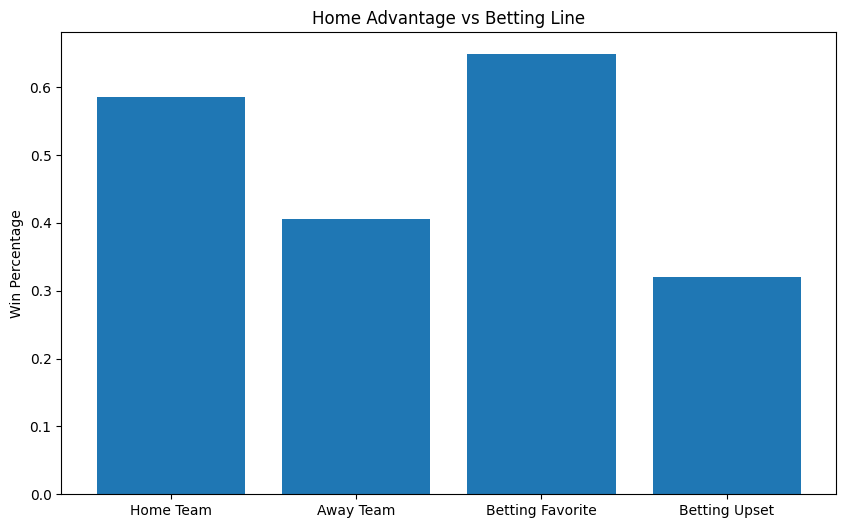

```python
plt.figure(figsize=(10, 6))
plt.bar(['Home Team', 'Away Team', 'Betting Favorite', 'Betting Upset'], [home_advantage, away_win, betting_favorite, betting_upset])
plt.title('Home Advantage vs Betting Line')
plt.ylabel('Win Percentage')
plt.show()
```

The above plot is showing the "home-advantage" and betting favorite effect. We can see that the betting favorite is more likely to win than the home team.

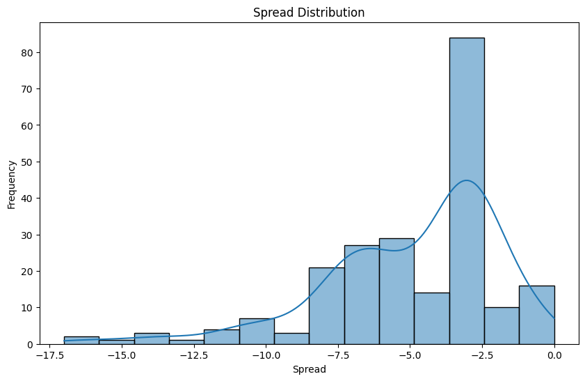

```python
plt.figure(figsize=(10, 6))
sns.histplot(merged_data['spread_favorite'], kde=True)
plt.title('Spread Distribution')
plt.xlabel('Spread')
plt.ylabel('Frequency')
plt.show()
```

The above plot is a histogram of the "spread" of the game. The spead is the expected point differential. We see that the plot is left skwere with a center around -5

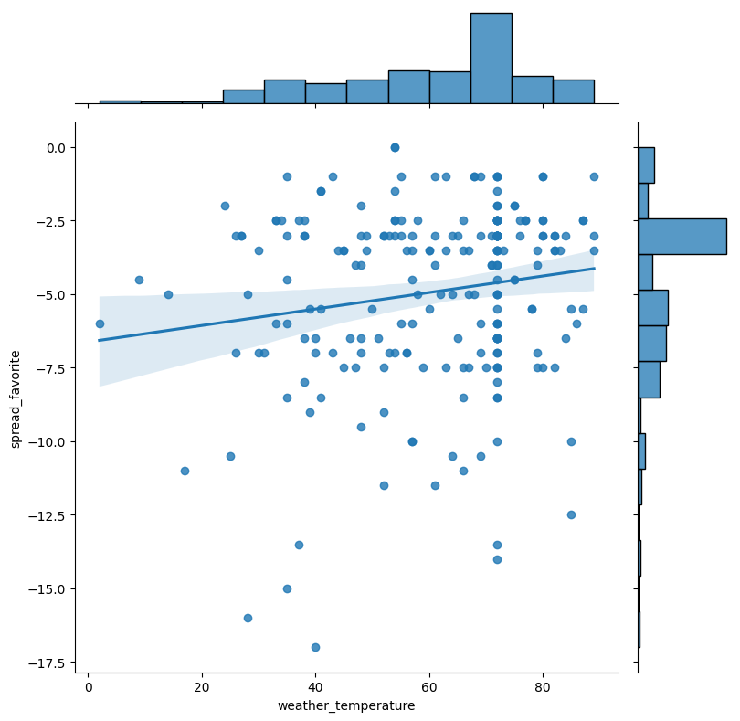

```python
g = sns.JointGrid(data=merged_data, x='weather_temperature',y='spread_favorite', height=8)
g = g.plot(sns.regplot, sns.histplot)
```

The scatterplot with a fitted regression line indicating a potential relationship between weather temperature and the betting spread for the favorite team in NFL games. As the temperature increases, the favorite team's expected winning margin slightly decreases. The histograms show most games occur at temperatures between 60-80°F and betting spreads are commonly set between -2.5 and -7.5 points. The plot suggests a possible trend where warmer weather is associated with closer games, but further analysis is needed to confirm any statistical significance.

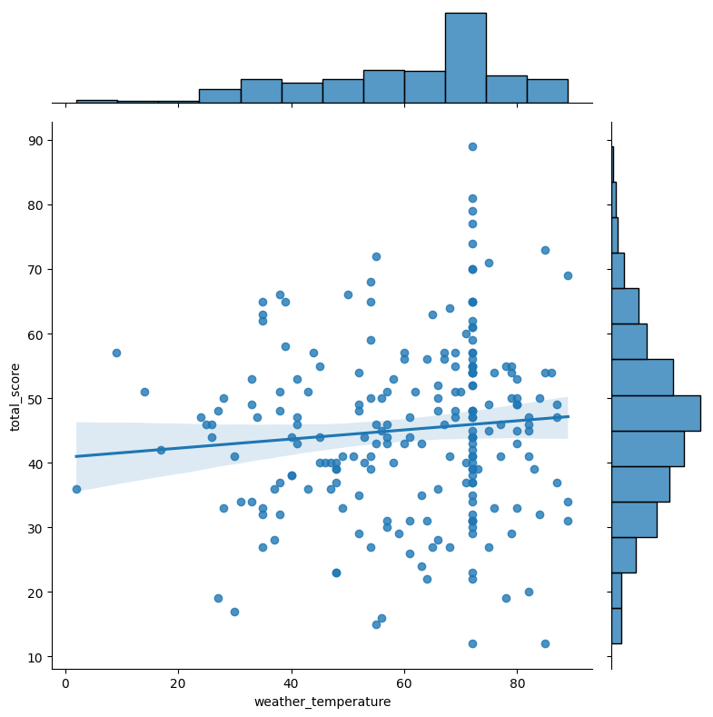

```python
merged_data['total_score'] = merged_data['home_score'] + merged_data['away_score']
g = sns.JointGrid(data=merged_data, x='weather_temperature',y='total_score', height=8)
g = g.plot(sns.regplot, sns.histplot)
```

The regression and dotplot of temperature by total score. We see that there is a weak positive relationship between the variables

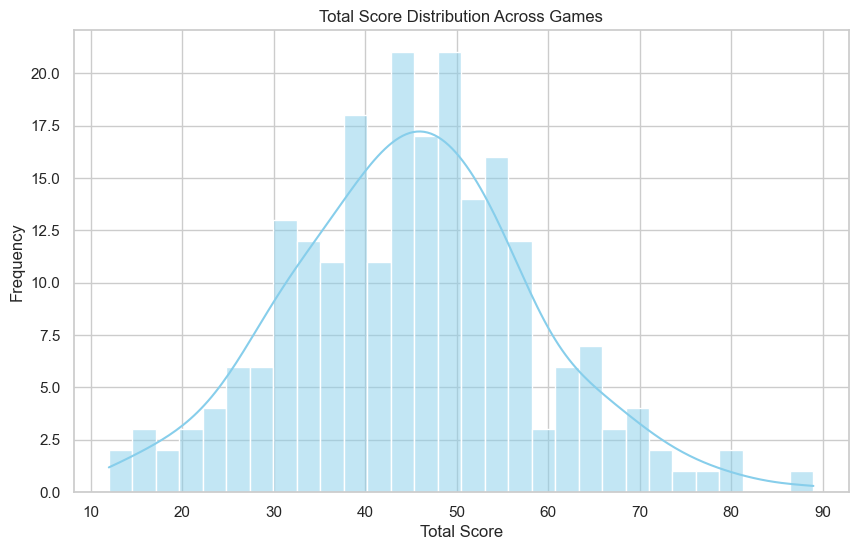

```python
sns.set(style="whitegrid")
plt.figure(figsize=(10, 6))
sns.histplot(merged_data['total_score'], kde=True, color='skyblue', bins=30)
plt.title('Total Score Distribution Across Games')
plt.xlabel('Total Score')
plt.ylabel('Frequency')
plt.show()
```

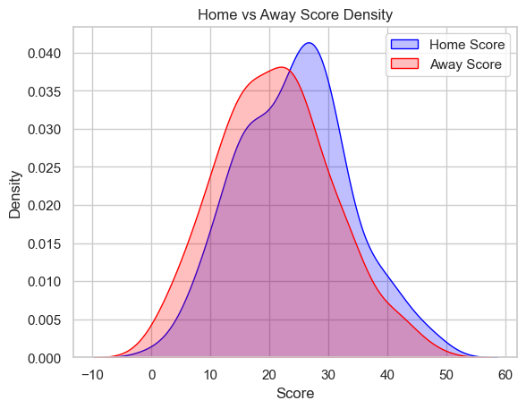

```python
sns.kdeplot(merged_data['home_score'], label='Home Score', shade=True, color='blue')
sns.kdeplot(merged_data['away_score'], label='Away Score', shade=True, color='red')
plt.title('Home vs Away Score Density')
plt.xlabel('Score')
plt.ylabel('Density')
plt.legend()
plt.show()
```

Above is a KDE Plot of the total score of NFL games separated by home and away team, we see that there are both are normally distributed with home team. The home team's distribution has a slightly higher peak than the away team's, indicating a higher density of scores around the mean for home teams.

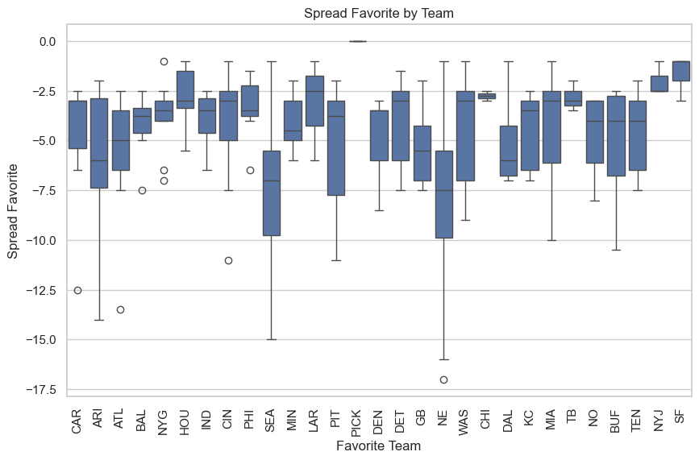

```python
plt.figure(figsize=(10, 6))
sns.boxplot(x='team_favorite_id', y='spread_favorite', data=merged_data)
plt.title('Spread Favorite by Team')
plt.xticks(rotation=90)
plt.xlabel('Favorite Team')
plt.ylabel('Spread Favorite')
plt.show()
```

Above is a plot of the showing the boxplot or distribution of the spread per team. We can see certain teams are expected to win by a larger margin. Such as NE (new england) and SEA (seattle)

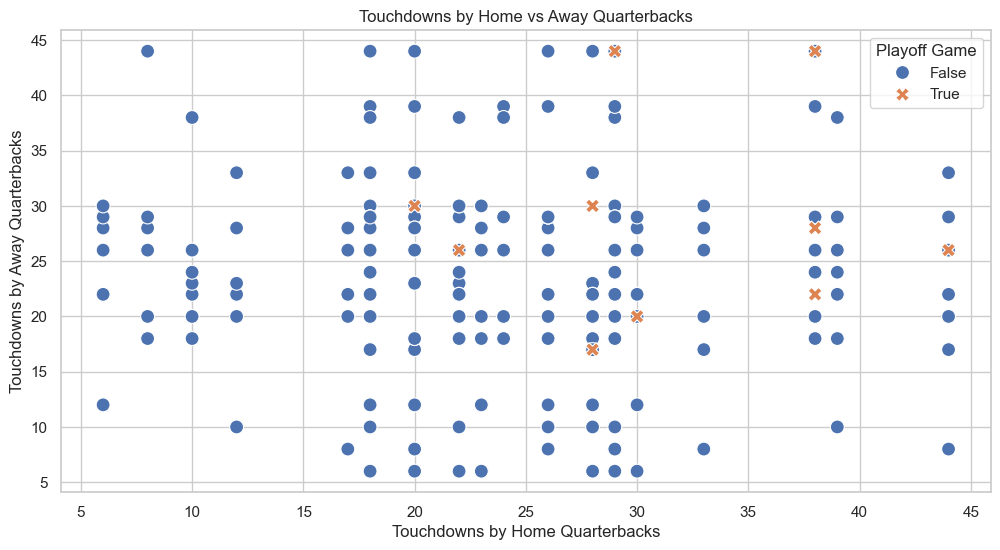

```python
plt.figure(figsize=(12, 6))
sns.scatterplot(x='TD_QB_home', y='TD_QB_away', hue='schedule_playoff', data=merged_data, style='schedule_playoff', s=100)
plt.title('Touchdowns by Home vs Away Quarterbacks')
plt.xlabel('Touchdowns by Home Quarterbacks')
plt.ylabel('Touchdowns by Away Quarterbacks')
plt.legend(title='Playoff Game')
plt.show()
```

The plot shows a wide distribution of touchdowns by both home and away quarterbacks, with no clear pattern of one outperforming the other significantly. There are instances in playoff games where both home and away quarterbacks have high touchdown counts, suggesting competitive performance in high-stakes games.

```python
# Aggregating home and away wins for each state
home_wins_by_state = merged_data.groupby('state')['home_win'].sum().reset_index()
away_wins_by_state = merged_data.groupby('state')['away_win'].sum().reset_index()

# Combining home and away wins by state
wins_by_state = pd.merge(home_wins_by_state, away_wins_by_state, on='state', how='outer')
wins_by_state['total_wins'] = wins_by_state['home_win'] + wins_by_state['away_win']

avg_crime_by_state = merged_data.groupby('state')[['Total Aggravated Assaults','Population']].mean().reset_index()

# Merging win data with crime data
state_analysis = pd.merge(wins_by_state, avg_crime_by_state, on='state')
```

```python
state_analysis['crime_rate']=state_analysis['Total Aggravated Assaults']/state_analysis['Population']
```

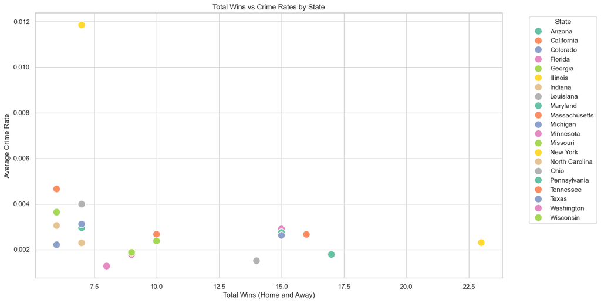

```python
# Visualizing the relationship between total wins and crime rates by state
plt.figure(figsize=(14, 8))
sns.scatterplot(x='total_wins', y='crime_rate', hue='state', data=state_analysis, palette='Set2', s=150)
plt.title('Total Wins vs Crime Rates by State')
plt.xlabel('Total Wins (Home and Away)')
plt.ylabel('Average Crime Rate')
plt.legend(title='State', bbox_to_anchor=(1.05, 1), loc='upper left')
plt.show()
```

In this plot the x-axis represents the total number of wins, and the y-axis represents the average crime rate. The points are spread across the plot, suggesting variability in both wins and crime rates across different states. Without further statistical analysis, it's not clear if there is a significant correlation between the two variables.

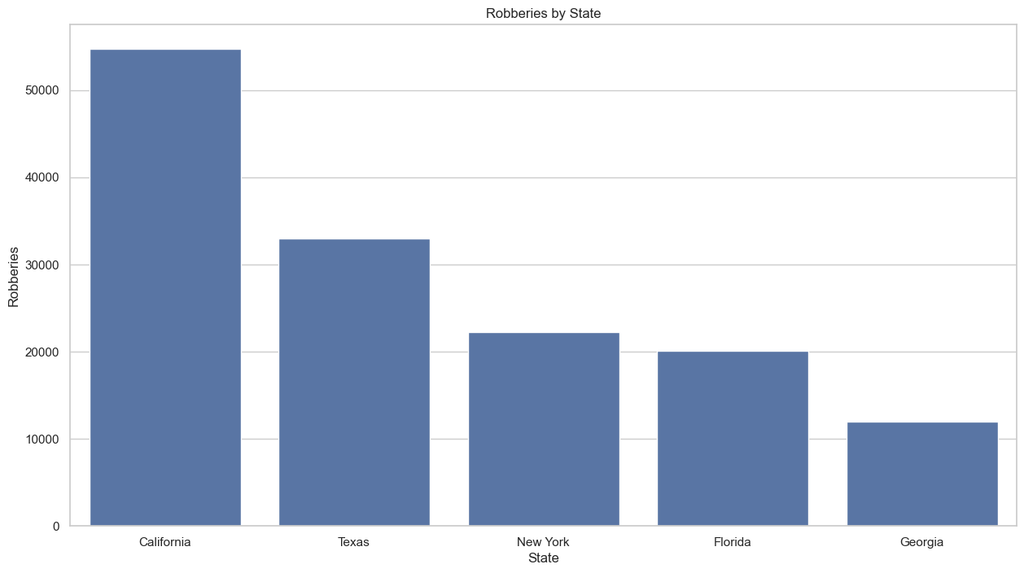

```python
plt.figure(figsize=(15, 8))
sns.barplot(x='State',y='Total\nrobberies1',data=robbery_data_reduced.sort_values(by='Total\nrobberies1', ascending= False).iloc[:5,:])
plt.title('Robberies by State')
plt.xlabel('State')
plt.ylabel('Robberies')
plt.show()
```

We can visualize the robberies data set using a barplot. The state of California has the higest Robberies among all the states, followed by texas.

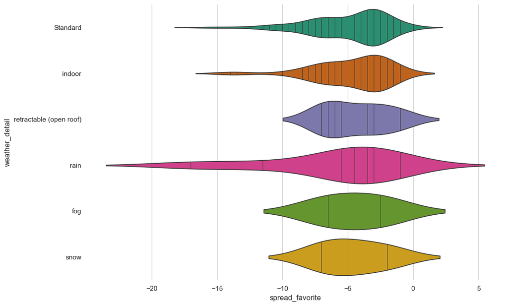

```python
figsize = (12,8)
plt.figure(figsize=figsize)
sns.violinplot(merged_data, x='spread_favorite', y='weather_detail', inner='stick', palette='Dark2')
sns.despine(top=True, right=True, bottom=True, left=True)
```

The violin plot visualizes the distribution of betting spreads for the favorite team across different weather conditions. The spread of data within each category shows the probability density of the spreads at different points. A quick glance indicates that the weather conditions might have varying impacts on the betting spreads,We can observe high variablity when it rains but without statistical analysis, we can't draw a definitive conclusion about the nature or significance of these impacts.